# 4 - Matplotlib Exercises

**Data**

```python
import numpy as np
x = np.arange(0, 100)
y = x*2
z = x**2
```

```python
import matplotlib.pyplot as plt
```

**1.**

- **Create a figure object called fig using plt.figure()**
- **Use add_axes to add an axis to the figure canvas at [0,0,1,1]. Call this new axis ax.**
- **Plot (x,y) on that axes and set the labels and titles to match the plot below:**

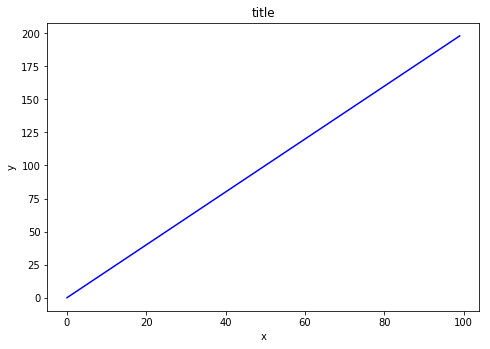

```python
fig = plt.figure()
axes = fig.add_axes([0,0,1,1])
axes.plot(x, y, 'b')
axes.set_title('title')
axes.set_xlabel('x')
axes.set_ylabel('y')
```

**2.** Create a figure object and put two axes on it, ax1 and ax2. Located at [0,0,1,1] and [0.2,0.5,.2,.2] respectively.

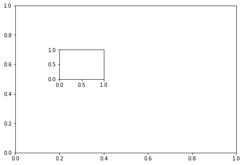

```python
fig = plt.figure()
axes1 = fig.add_axes([0,0,1,1])
axes2 = fig.add_axes([0.2,0.5,0.2,0.2])
```

Now plot (x,y) on both axes. And call your figure object to show it.

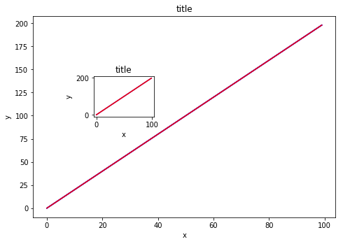

```python
axes1.plot(x, y, 'r')
axes1.set_title('title')
axes1.set_xlabel('x')
axes1.set_ylabel('y')

axes2.plot(x,y, 'r')
axes2.set_title('title')
axes2.set_xlabel('x')
axes2.set_ylabel('y')
fig
```

**3.** Create a figure object and put two axes on it, ax1 and ax2. Located at [0,0,1,1] and [0.2,0.5,.4,.4] respectively.

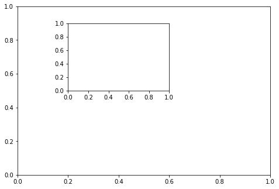

```python
fig = plt.figure()
axes1 = fig.add_axes([0,0,1,1])
axes2 = fig.add_axes([0.2,0.5,.4,.4])
```

**Now use x,y, and z arrays to recreate the plot below. Notice the xlimits and y limits on the inserted plot:**

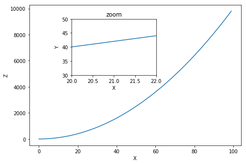

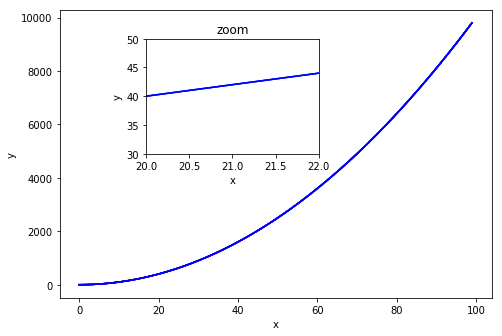

```python
axes1.plot(x, z, 'b')
axes1.set_xlabel('x')
axes1.set_ylabel('y')

axes2.plot(x, y, 'b')
axes2.set_xlim(20, 22)
axes2.set_ylim(30, 50)
axes2.set_xlabel('x')
axes2.set_ylabel('y')
axes2.set_title('zoom')

fig
```

**4.** Use plt.subplots(nrows=1, ncols=2) to create the plot below.

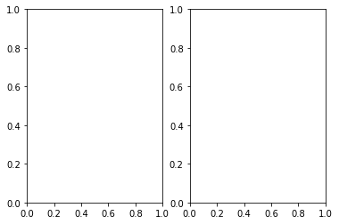

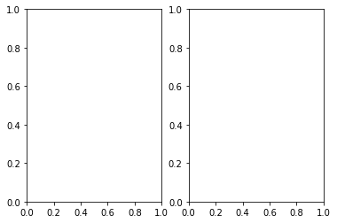

```python
fig, axes = plt.subplots(nrows=1, ncols=2)
```

**Now plot (x,y) and (x,z) on the axes. Play around with the linewidth and style**

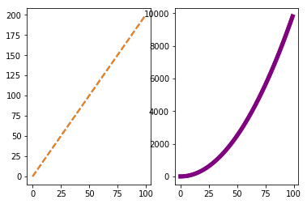

```python
axes[0].plot(x,y, ls='--', lw=2)
axes[1].plot(x,z, ls='-', lw=5, color='purple')
fig
```

**See if you can resize the plot by adding the figsize() argument in plt.subplots() are copying and pasting your previous code.**

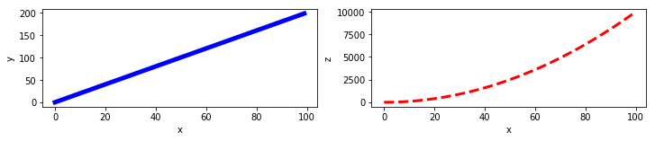

```python
fig, axes = plt.subplots(nrows=1, ncols=2,figsize=(12,2))

axes[0].plot(x,y,color="blue", lw=5)
axes[0].set_xlabel('x')
axes[0].set_ylabel('y')

axes[1].plot(x,z,color="red", lw=3, ls='--')
axes[1].set_xlabel('x')
axes[1].set_ylabel('z')
```